# Research Question

Customers’ choice is a market research firm. We have been approached by a client who is an automobile business owner. This client has tasked us to help identify different segments (groups) to which her customers belong.

# 1 Problem Definition

Customer segmentation is the practice of partitioning a customer into groups of individuals that have similar characteristics. Our aim is to identify customers best suited for the clients’ automobile products.

# 2 Data source and description

Our data is about customers of a certain business and their characteristics and was sourced from Kaggle in the following link https://www.kaggle.com/yashgupta011/customer-segmentation-dataset?select=Customer_Segmentation.csv The data has 850 rows and 10 columns.

# Experimental design

1. Problem Definition
2. Data Sourcing
3. Check the Data
4. Perform Data Cleaning
5. Perform Exploratory Data Analysis
6. Implement the Solution
7. Challenging the solution
8. Recommendation

# 3 Checking the data

```r
# Loading our dataset
library(readr)
Customer_Segmentation <- read_csv("C:/Users/mcmug/Desktop/Customer_Segmentation.csv")
View(Customer_Segmentation)
```

```r
### Installing packages
#install.packages("psych")

#install.packages("Amelia")

#install.packages("vqv/ggbiplot")

#install.packages("gridExtra")

#install.packages("devtools")

#install.packages("GGally")

#install.packages("factoextra")
```

```r
# loading libraries
library(dplyr)
library(magrittr)
library(knitr)
library(purrr)
library(dplyr)
library(psych)
library(tidyverse)
library(Amelia)
```

```r
library(ggplot2)
library(corrplot)
library(gridExtra)
library(ggcorrplot)
library(moments)
library(devtools)
library(cluster)
library(factoextra)
library(GGally)
# previewing top of our dataset
head(Customer_Segmentation)
```

```
## # A tibble: 6 x 10
##   `Customer Id`   Age   Edu `Years Employed` Income `Card Debt` `Other Debt`
##           <dbl> <dbl> <dbl>            <dbl>  <dbl>       <dbl>        <dbl>
## 1             1    41     2                6     19       0.124        1.07
## 2             2    47     1               26    100       4.58         8.22
## 3             3    33     2               10     57       6.11         5.80
## 4             4    29     2                4     19       0.681        0.516
## 5             5    47     1               31    253       9.31         8.91
## 6             6    40     1               23     81       0.998        7.83
## # ... with 3 more variables: Defaulted <dbl>, Address <chr>,
## #   DebtIncomeRatio <dbl>
```

```r
# Getting the column names
attributes(Customer_Segmentation)$names
```

```
##  [1] "Customer Id"     "Age"             "Edu"             "Years Employed"
##  [5] "Income"          "Card Debt"       "Other Debt"      "Defaulted"
##  [9] "Address"         "DebtIncomeRatio"
```

```r
# Getting the class ofthe data
attributes(Customer_Segmentation)$class
```

```
## [1] "spec_tbl_df" "tbl_df"      "tbl"         "data.frame"
```

```r
# Taking a glimpse on some of the data in the dataset
glimpse(Customer_Segmentation)
```

```
## Rows: 850
## Columns: 10
## $ `Customer Id`    <dbl> 1, 2, 3, 4, 5, 6, 7, 8, 9, 10, 11, 12, 13, 14, 15,...
## $ Age              <dbl> 41, 47, 33, 29, 47, 40, 38, 42, 26, 47, 44, 34, 24...
## $ Edu              <dbl> 2, 1, 2, 2, 1, 1, 2, 3, 1, 3, 3, 2, 1, 1, 3, 1, 1,...
## $ `Years Employed` <dbl> 6, 26, 10, 4, 31, 23, 4, 0, 5, 23, 8, 9, 7, 6, 2, ...
## $ Income           <dbl> 19, 100, 57, 19, 253, 81, 56, 64, 18, 115, 88, 40,...
## $ `Card Debt`      <dbl> 0.124, 4.582, 6.111, 0.681, 9.308, 0.998, 0.442, 0...
## $ `Other Debt`     <dbl> 1.073, 8.218, 5.802, 0.516, 8.908, 7.831, 0.454, 3...
## $ Defaulted        <dbl> 0, 0, 1, 0, 0, NA, 0, 0, NA, 0, 1, NA, 0, NA, 1, N...
## $ Address          <chr> "NBA001", "NBA021", "NBA013", "NBA009", "NBA008", ...
## $ DebtIncomeRatio  <dbl> 6.3, 12.8, 20.9, 6.3, 7.2, 10.9, 1.6, 6.6, 15.5, 4...
```

```r
# Checking some statistical summaries of the data
summary(Customer_Segmentation)
```

```
##   Customer Id         Age             Edu        Years Employed
##  Min.   :  1.0   Min.   :20.00   Min.   :1.000   Min.   : 0.000
##  1st Qu.:213.2   1st Qu.:29.00   1st Qu.:1.000   1st Qu.: 3.000
##  Median :425.5   Median :34.00   Median :1.000   Median : 7.000
##  Mean   :425.5   Mean   :35.03   Mean   :1.711   Mean   : 8.566
##  3rd Qu.:637.8   3rd Qu.:41.00   3rd Qu.:2.000   3rd Qu.:13.000
##  Max.   :850.0   Max.   :56.00   Max.   :5.000   Max.   :33.000
##
##      Income         Card Debt         Other Debt       Defaulted
##  Min.   : 13.00   Min.   : 0.0120   Min.   : 0.046   Min.   :0.0000
##  1st Qu.: 24.00   1st Qu.: 0.3825   1st Qu.: 1.046   1st Qu.:0.0000
##  Median : 35.00   Median : 0.8850   Median : 2.003   Median :0.0000
##  Mean   : 46.68   Mean   : 1.5768   Mean   : 3.079   Mean   :0.2614
##  3rd Qu.: 55.75   3rd Qu.: 1.8985   3rd Qu.: 3.903   3rd Qu.:1.0000
##  Max.   :446.00   Max.   :20.5610   Max.   :35.197   Max.   :1.0000
##                                                      NA's   :150
##    Address          DebtIncomeRatio
##  Length:850         Min.   : 0.10
##  Class :character   1st Qu.: 5.10
##  Mode  :character   Median : 8.70
##                     Mean   :10.17
##                     3rd Qu.:13.80
##                     Max.   :41.30
##
```

```r
# Checking for the dimensions of the dataset
dim(Customer_Segmentation)
```

```
## [1] 850  10
```

Our data contains 10 columns and 850 rows

# 4 Perform Data Cleaning

## 4.1 Changing the names of the columns to lower case

```r
### Changing the names of the columns to lower

colnames(Customer_Segmentation) <- tolower(str_replace_all(colnames(Customer_Segmentation), c(' ' = '_')))
colnames(Customer_Segmentation)
```

```
##  [1] "customer_id"     "age"             "edu"             "years_employed"
##  [5] "income"          "card_debt"       "other_debt"      "defaulted"
##  [9] "address"         "debtincomeratio"
```

## 4.2 Checking for Missing values

```r
### Checking for Missing values

colSums(is.na(Customer_Segmentation))
```

```
##     customer_id             age             edu  years_employed          income
##               0               0               0               0               0
##       card_debt      other_debt       defaulted         address debtincomeratio
##               0               0             150               0               0
```

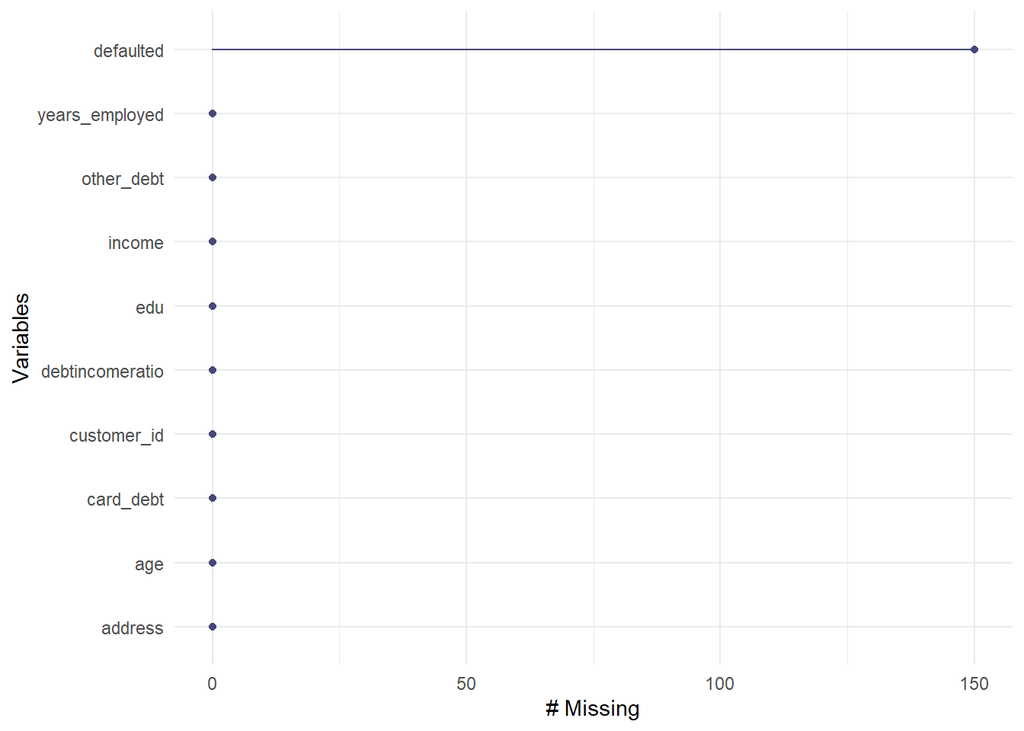

```r
#  visualizing missing data
#install.packages("naniar")
library(naniar)
gg_miss_var(Customer_Segmentation)
```

there are 150 missing values in defaulted column

```r
#calculating percentage of missing data
miss_var_summary(Customer_Segmentation)
```

```
## # A tibble: 10 x 3
##    variable        n_miss pct_miss
##    <chr>            <int>    <dbl>
##  1 defaulted          150     17.6
##  2 customer_id          0      0
##  3 age                  0      0
##  4 edu                  0      0
##  5 years_employed       0      0
##  6 income               0      0
##  7 card_debt            0      0
##  8 other_debt           0      0
##  9 address              0      0
## 10 debtincomeratio      0      0
```

```r
### Dealing with missing values
data <- na.omit(Customer_Segmentation)
```

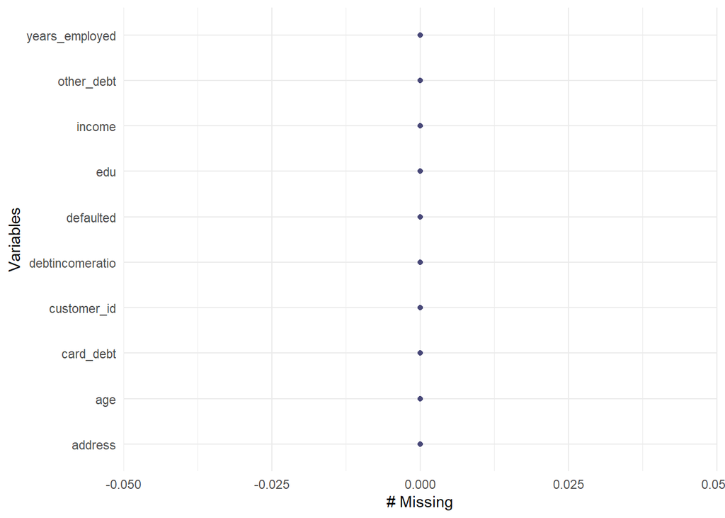

```r
### verifying there are no missing values values
gg_miss_var(data)
```

## 4.3 Checking for duplicates

```r
### Checking for duplicates

anyDuplicated(data)
```

```
## [1] 0
```

there are no duplicates

## 4.4 Checking for outliers

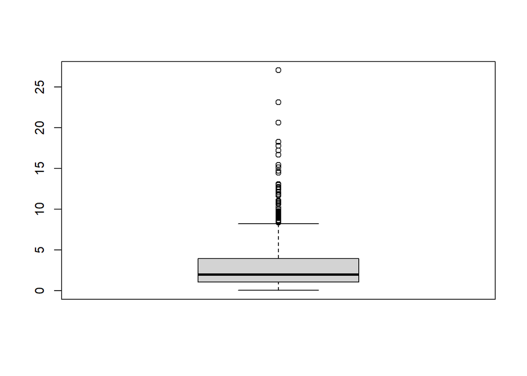

```r
### Checking for outliers
boxplot(data$other_debt)
```

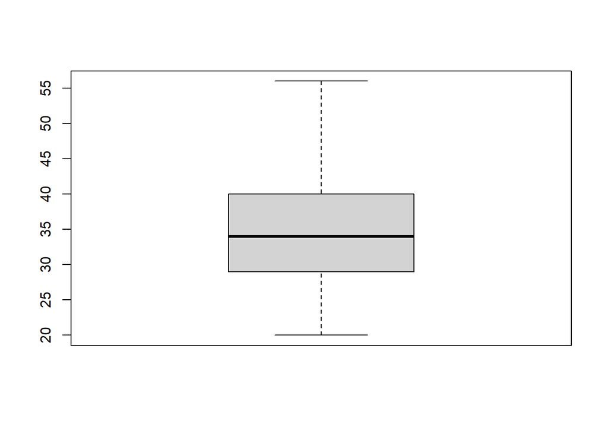

```r
boxplot(data$age)
```

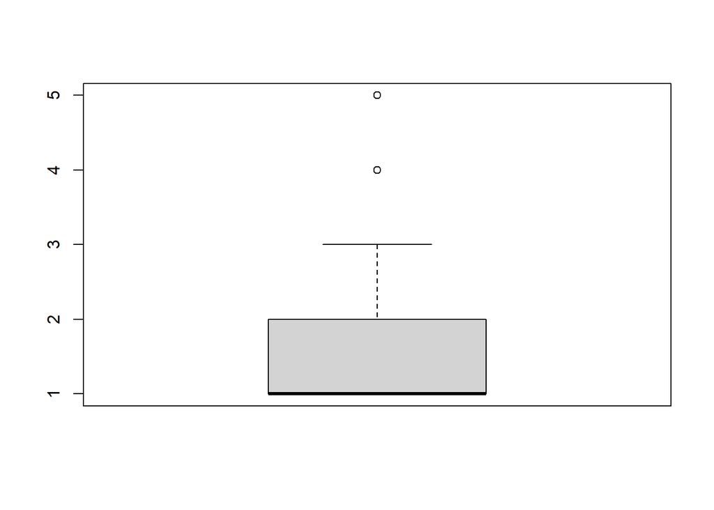

```r
boxplot(data$edu)
```

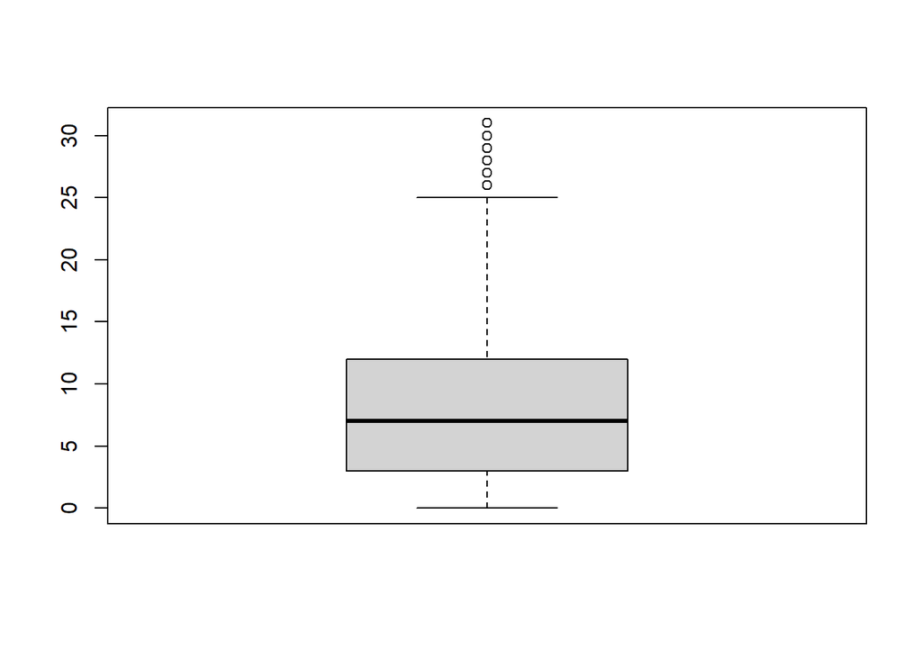

```r
boxplot(data$years_employed)
```

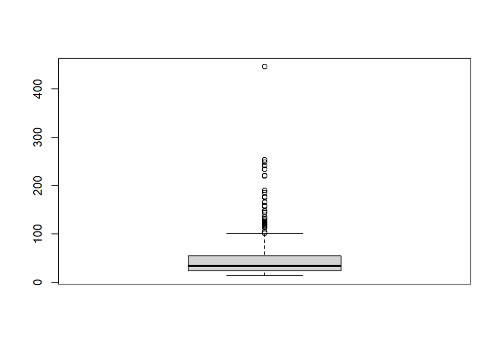

```r
boxplot(data$income)
```

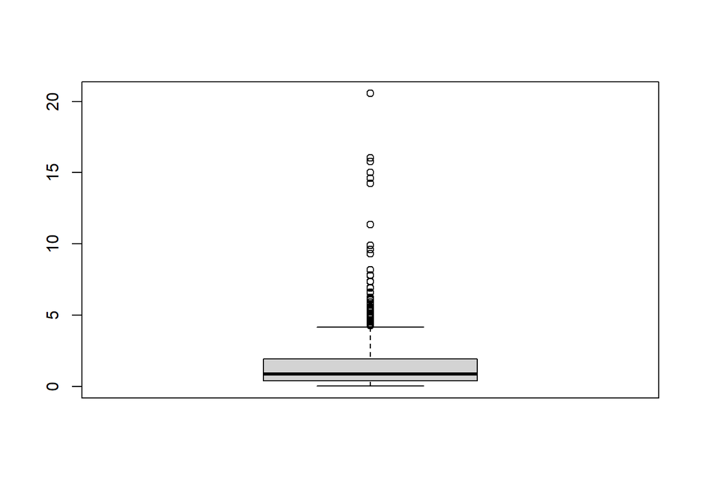

```r
boxplot(data$card_debt)
```

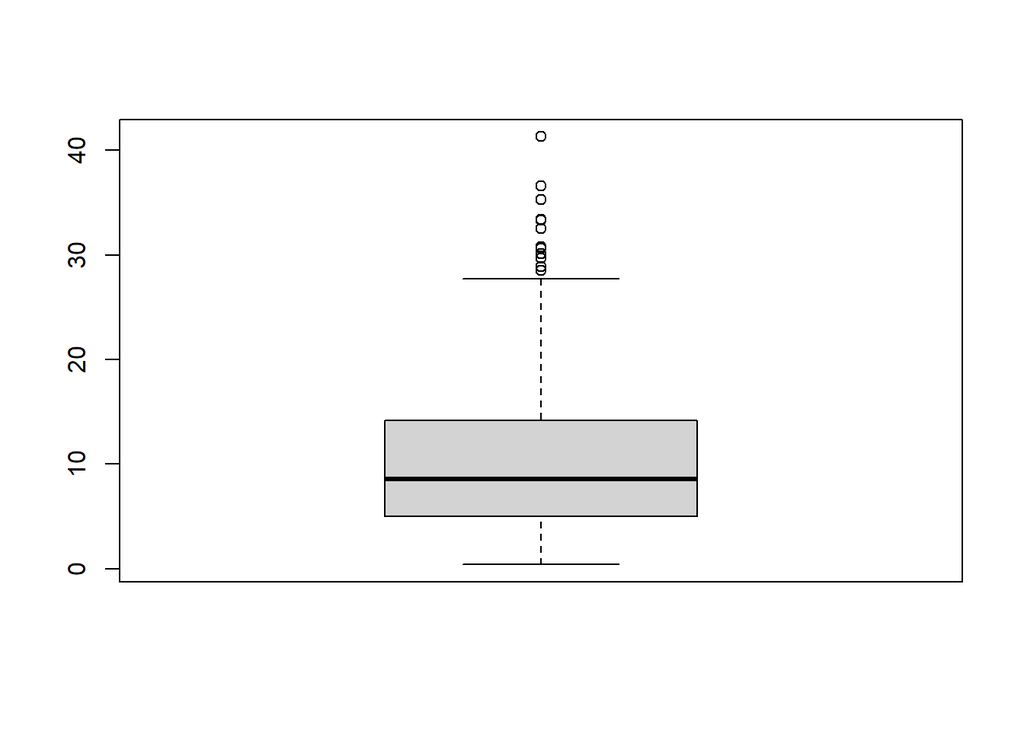

```r
boxplot(data$debtincomeratio)
```

we noted some outliers but we didnt drop them because they might provide more insights as we do analysis

# 5 EDA

## 5.1 univariate

```r
# selecting numerical variables
num<-data[,-c(1,9)]
```

```r
# getting the modes of numerical variables
Modes <- function(x) {
  ux <- unique(x)
  tab <- tabulate(match(x, ux))
  ux[tab == max(tab)]
}
lapply(num, Modes)
```

```
## $age
## [1] 29
##
## $edu
## [1] 1
##
## $years_employed
## [1] 0
##
## $income
## [1] 25
##
## $card_debt
## [1] 0.694
##
## $other_debt
## [1] 1.073 0.469
##
## $defaulted
## [1] 0
##
## $debtincomeratio
## [1] 4.5
```

```r
# getting the standard deviation of numerical variables
lapply(num, sd)
```

```
## $age
## [1] 7.997342
##
## $edu
## [1] 0.9282055
##
## $years_employed
## [1] 6.658039
##
## $income
## [1] 36.81423
##
## $card_debt
## [1] 2.117196
##
## $other_debt
## [1] 3.28755
##
## $defaulted
## [1] 0.4397271
##
## $debtincomeratio
## [1] 6.827234
```

```r
# getting the mean of  variables
lapply(num, mean)
```

```
## $age
## [1] 34.86
##
## $edu
## [1] 1.722857
##
## $years_employed
## [1] 8.388571
##
## $income
## [1] 45.60143
##
## $card_debt
## [1] 1.553566
##
## $other_debt
## [1] 3.058196
##
## $defaulted
## [1] 0.2614286
##
## $debtincomeratio
## [1] 10.26057
```

```r
# getting the median of  variables
lapply(num, median)
```

```
## $age
## [1] 34
##
## $edu
## [1] 1
##
## $years_employed
## [1] 7
##
## $income
## [1] 34
##
## $card_debt
## [1] 0.855
##
## $other_debt
## [1] 1.9875
##
## $defaulted
## [1] 0
##
## $debtincomeratio
## [1] 8.6
```

```r
# getting the variance of  variables
lapply(num, var)
```

```
## $age
## [1] 63.95748
##
## $edu
## [1] 0.8615655
##
## $years_employed
## [1] 44.32948
##
## $income
## [1] 1355.287
##
## $card_debt
## [1] 4.482519
##
## $other_debt
## [1] 10.80799
##
## $defaulted
## [1] 0.1933599
##
## $debtincomeratio
## [1] 46.61112
```

```r
# getting the minimum values of  variables
lapply(num, min)
```

```
## $age
## [1] 20
##
## $edu
## [1] 1
##
## $years_employed
## [1] 0
##
## $income
## [1] 14
##
## $card_debt
## [1] 0.012
##
## $other_debt
## [1] 0.046
##
## $defaulted
## [1] 0
##
## $debtincomeratio
## [1] 0.4
```

```r
# getting the mean of  variables
lapply(num, max)
```

```
## $age
## [1] 56
##
## $edu
## [1] 5
##
## $years_employed
## [1] 31
##
## $income
## [1] 446
##
## $card_debt
## [1] 20.561
##
## $other_debt
## [1] 27.034
##
## $defaulted
## [1] 1
##
## $debtincomeratio
## [1] 41.3
```

```r
# getting the range of  variables
lapply(num, range)
```

```
## $age
## [1] 20 56
##
## $edu
## [1] 1 5
##
## $years_employed
## [1]  0 31
##
## $income
## [1]  14 446
##
## $card_debt
## [1]  0.012 20.561
##
## $other_debt
## [1]  0.046 27.034
##
## $defaulted
## [1] 0 1
##
## $debtincomeratio
## [1]  0.4 41.3
```

```r
# getting the kurtosis of  variables
lapply(num, kurtosis)
```

```
## $age
## [1] 2.38519
##
## $edu
## [1] 3.730095
##
## $years_employed
## [1] 3.222458
##
## $income
## [1] 28.97449
##
## $card_debt
## [1] 24.81355
##
## $other_debt
## [1] 13.24747
##
## $defaulted
## [1] 2.179102
##
## $debtincomeratio
## [1] 4.201328
```

```r
# getting the skewness of  variables
lapply(num, skewness)
```

```
## $age
## [1] 0.3607031
##
## $edu
## [1] 1.198744
##
## $years_employed
## [1] 0.8293715
##
## $income
## [1] 3.850475
##
## $card_debt
## [1] 3.890129
##
## $other_debt
## [1] 2.72234
##
## $defaulted
## [1] 1.085865
##
## $debtincomeratio
## [1] 1.093713
```

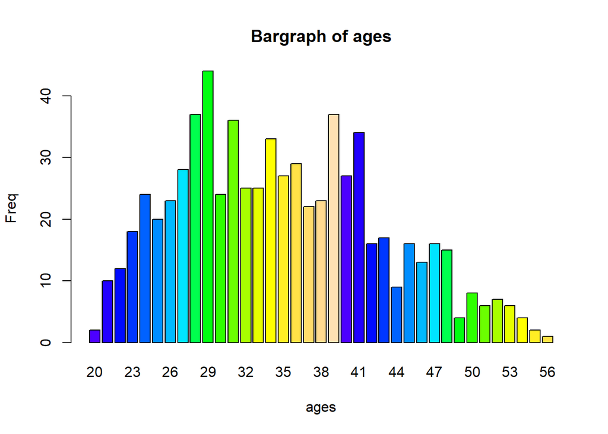

```r
# Plotting barplot
barplot(table(data$age),
main = "Bargraph of ages",
xlab = "ages",
ylab = "Freq",
col = topo.colors(20),
horiz = FALSE)
```

the age of the youngest customer is 20 ,while the oldest is 56,most customers are 29 years old

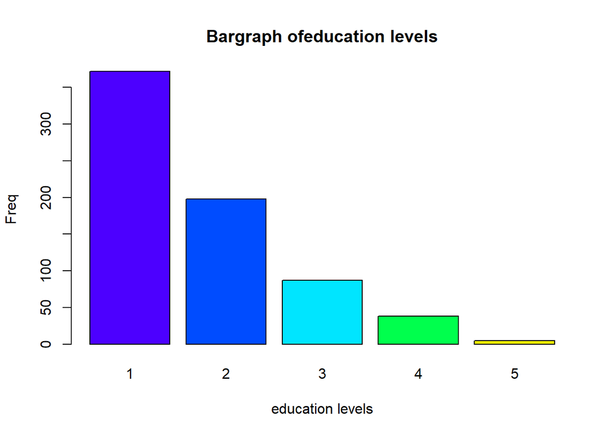

```r
# Plotting barplot
barplot(table(data$edu),
main = "Bargraph ofeducation levels",
xlab = "education levels",
ylab = "Freq",
col = topo.colors(5),
horiz = FALSE)
```

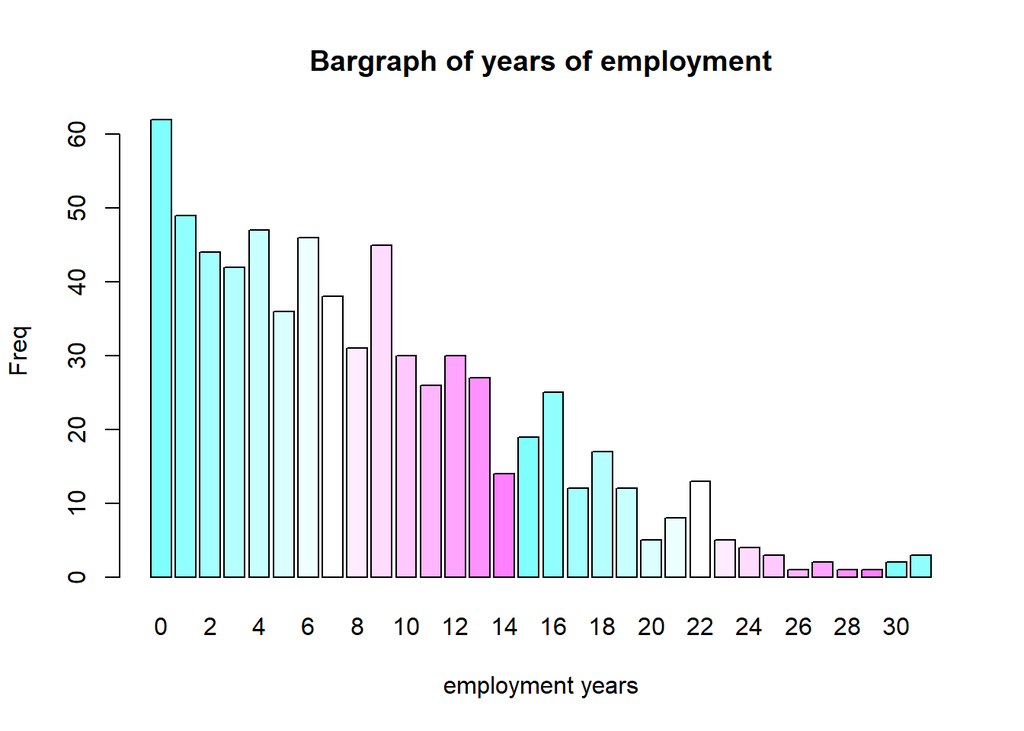

```r
# Plotting barplot
barplot(table(data$years_employed),
main = "Bargraph of years of employment",
xlab = "employment years",
ylab = "Freq",
col = cm.colors(15),
horiz = FALSE)
```

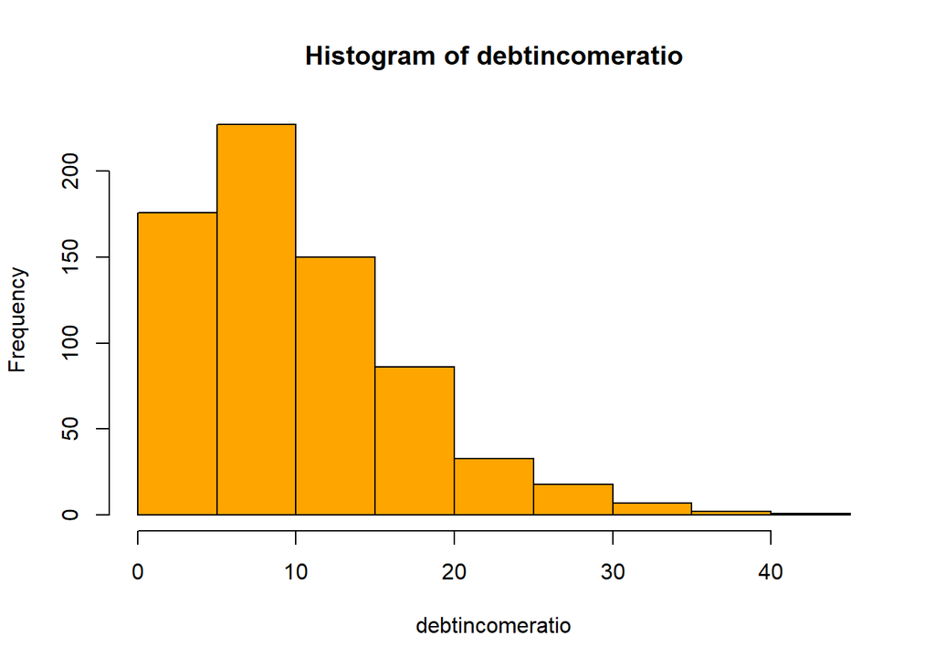

```r
hist(data$debtincomeratio,
     main = "Histogram of debtincomeratio",
     xlab = "debtincomeratio", col = "orange")
```

The histogram is positively skewed meaning most customers have a low debt income ratio

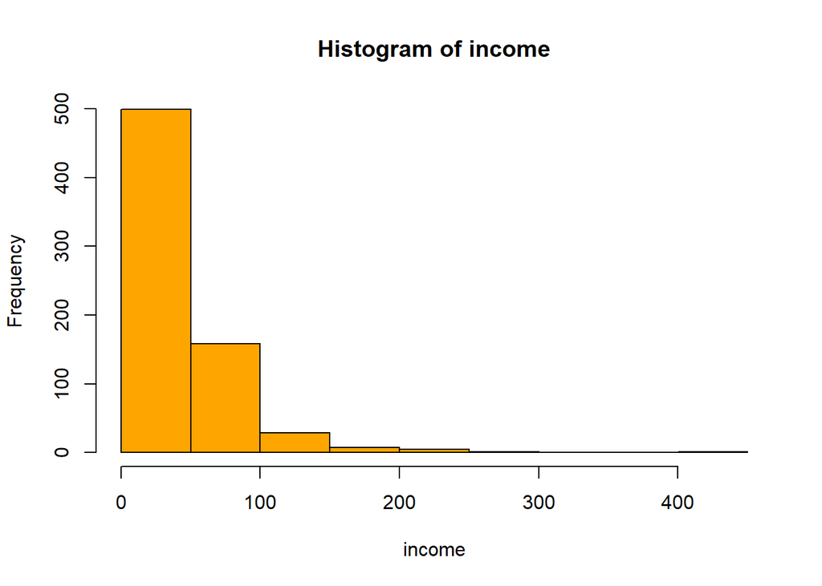

```r
hist(data$income,
     main = "Histogram of income",
     xlab = "income", col = "orange")
```

the histogram is positively skewed meaning most customers have a low income

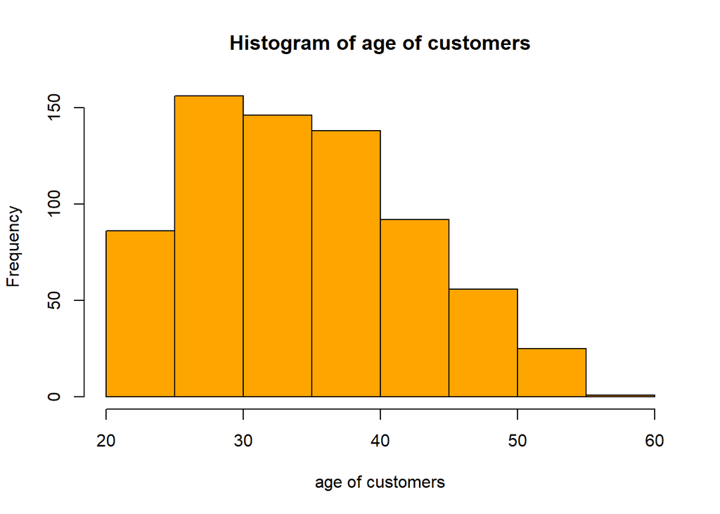

```r
hist(data$age,
     main = "Histogram of age of customers",
     xlab = "age of customers", col = "orange")
```

Most customers range between the ages of 25 to 40

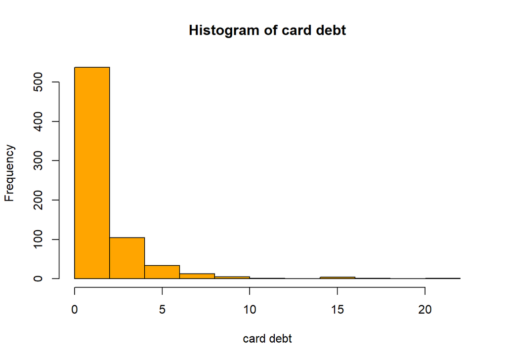

```r
hist(data$card_debt,
     main = "Histogram of card debt",
     xlab = "card debt", col = "orange")
```

Most customers have a low card debt of 0 to 2

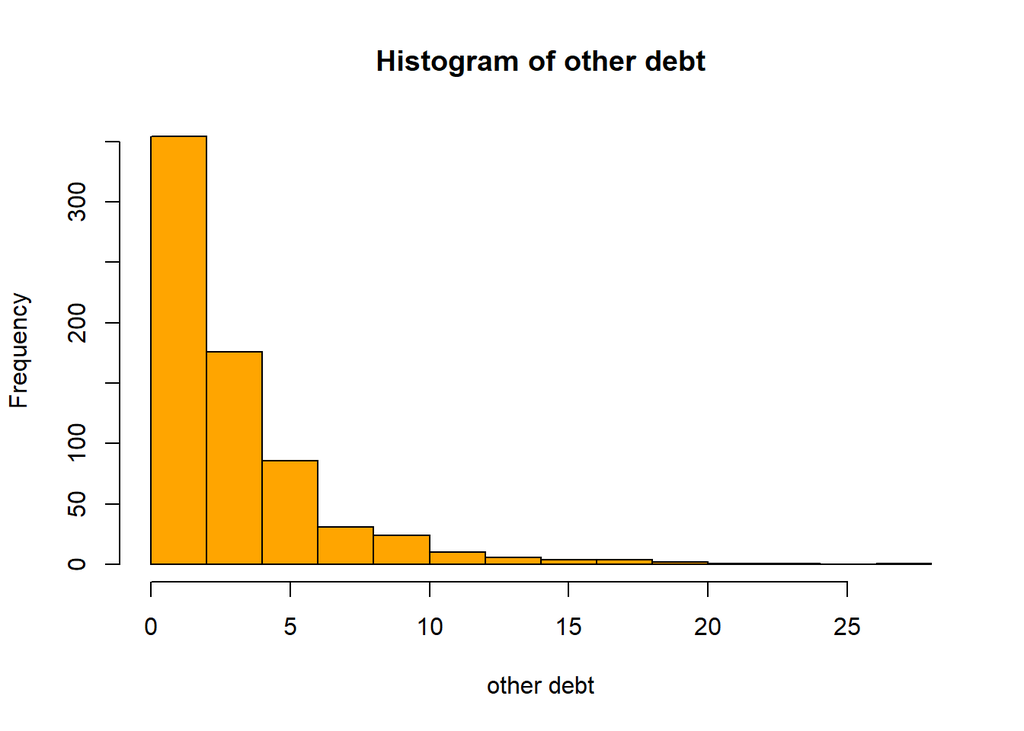

```r
hist(data$other_debt,
     main = "Histogram of other debt",
     xlab = "other debt", col = "orange")
```

Most customers have a low other debt of 0 to 2

## Bivariate

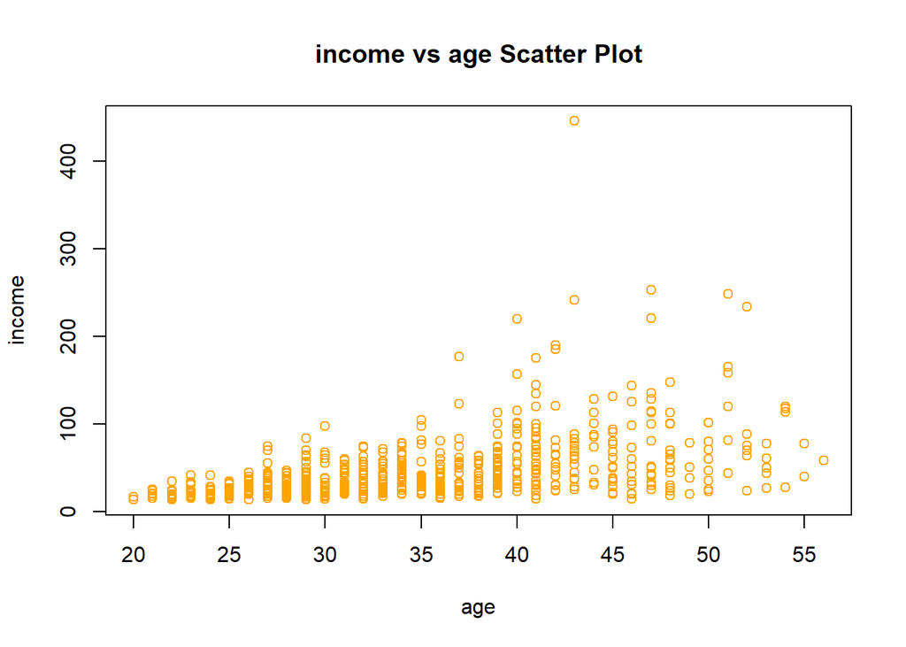

```r
plot(income ~ age, data = data,
      col = "orange",
      main = "income vs age Scatter Plot")
```

there is a positive correlation between age and income, as age increases so does income

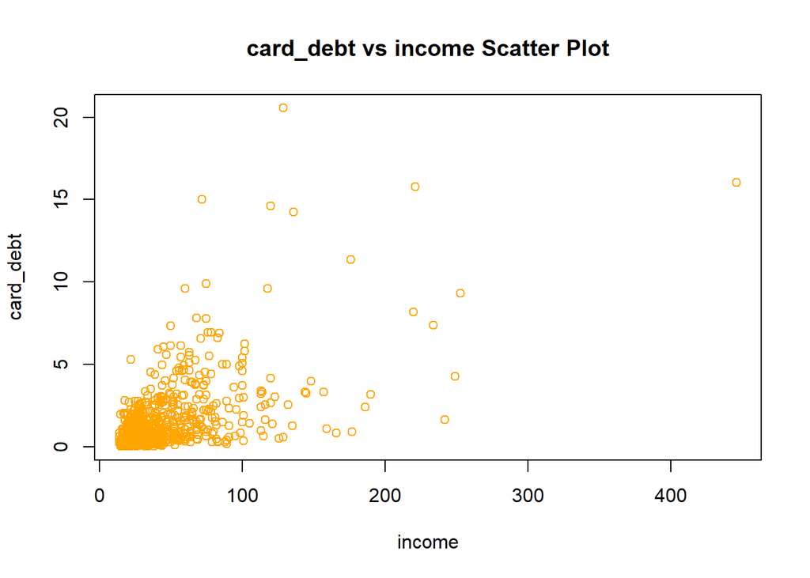

```r
plot( card_debt~ income, data = data,
      col = "orange",
      main = "card_debt vs income Scatter Plot")
```

customers with a low income have a low card debt

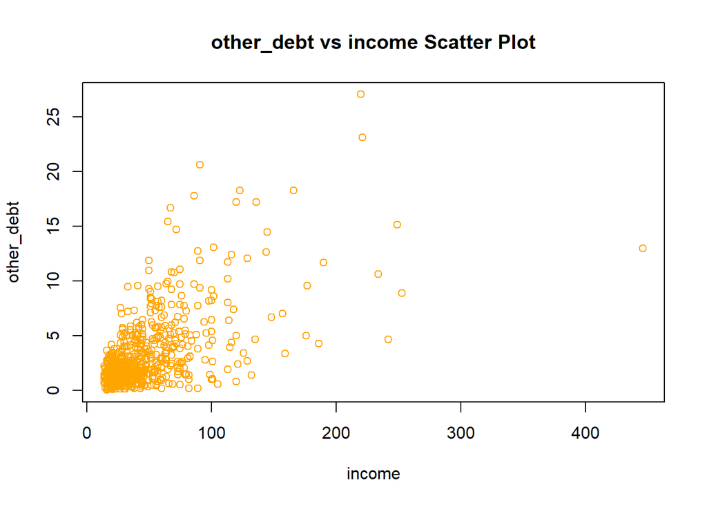

```r
plot( other_debt~ income, data = data,
      col = "orange",
      main = "other_debt vs income Scatter Plot")
```

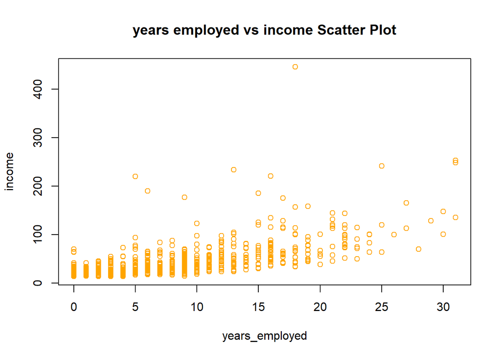

```r
plot( income ~ years_employed, data = data,
      col = "orange",
      main = "years employed vs income Scatter Plot")
```

as a customer works more years,their income increases

```r
# Calculate the correlations
corr <- cor(num [,-c(7)])
corr
```

```
##                        age          edu years_employed      income  card_debt
## age             1.00000000  0.022325004     0.53649678  0.47870987 0.29521432
## edu             0.02232500  1.000000000    -0.15362077  0.23519050 0.08827721
## years_employed  0.53649678 -0.153620770     1.00000000  0.61968132 0.40369784
## income          0.47870987  0.235190498     0.61968132  1.00000000 0.57019584
## card_debt       0.29521432  0.088277211     0.40369784  0.57019584 1.00000000
## other_debt      0.34021296  0.165458328     0.40608937  0.61066266 0.63310841
## debtincomeratio 0.01639808  0.008838431    -0.03118221 -0.02677729 0.50177245
##                 other_debt debtincomeratio
## age              0.3402130     0.016398077
## edu              0.1654583     0.008838431
## years_employed   0.4060894    -0.031182215
## income           0.6106627    -0.026777293
## card_debt        0.6331084     0.501772450
## other_debt       1.0000000     0.584867409
## debtincomeratio  0.5848674     1.000000000
```

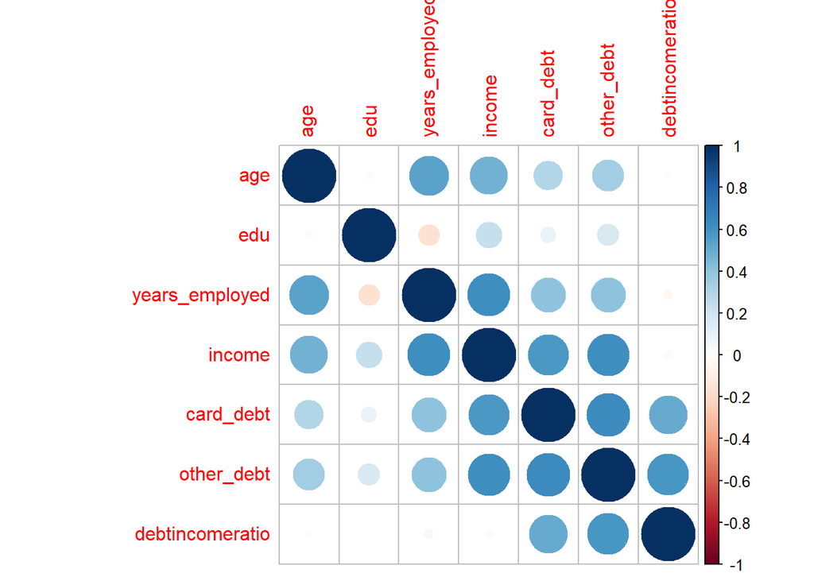

```r
corrplot(corr, method="circle")
```

# 6 Implement the Solution

```r
# removing columns that are not important in clustering,
clusterdata<-data[, -c(1,9)]
head(clusterdata)
```

```
## # A tibble: 6 x 8
##     age   edu years_employed income card_debt other_debt defaulted
##   <dbl> <dbl>          <dbl>  <dbl>     <dbl>      <dbl>     <dbl>
## 1    41     2              6     19     0.124      1.07          0
## 2    47     1             26    100     4.58       8.22          0
## 3    33     2             10     57     6.11       5.80          1
## 4    29     2              4     19     0.681      0.516         0
## 5    47     1             31    253     9.31       8.91          0
## 6    38     2              4     56     0.442      0.454         0
## # ... with 1 more variable: debtincomeratio <dbl>
```

```r
# Previewing the clusterdata

head(clusterdata)
```

```
## # A tibble: 6 x 8
##     age   edu years_employed income card_debt other_debt defaulted
##   <dbl> <dbl>          <dbl>  <dbl>     <dbl>      <dbl>     <dbl>
## 1    41     2              6     19     0.124      1.07          0
## 2    47     1             26    100     4.58       8.22          0
## 3    33     2             10     57     6.11       5.80          1
## 4    29     2              4     19     0.681      0.516         0
## 5    47     1             31    253     9.31       8.91          0
## 6    38     2              4     56     0.442      0.454         0
## # ... with 1 more variable: debtincomeratio <dbl>
```

```r
# Normalizing the dataset so that no particular attribute
# has more impact on clustering algorithm than others.


normalize <- function(x){
  return ((x-min(x)) / (max(x)-min(x)))
}
```

```r
dfnormalized <- as.data.frame(apply(clusterdata, 2, function(x) (x - min(x))/(max(x)-min(x))))
```

```r
head(dfnormalized)
```

```
##         age  edu years_employed     income   card_debt other_debt defaulted
## 1 0.5833333 0.25      0.1935484 0.01157407 0.005450387 0.03805395         0
## 2 0.7500000 0.00      0.8387097 0.19907407 0.222395250 0.30280124         0
## 3 0.3611111 0.25      0.3225806 0.09953704 0.296802764 0.21327998         1
## 4 0.2500000 0.25      0.1290323 0.01157407 0.032556329 0.01741515         0
## 5 0.7500000 0.00      1.0000000 0.55324074 0.452382111 0.32836816         0
## 6 0.5000000 0.25      0.1290323 0.09722222 0.020925592 0.01511783         0
##   debtincomeratio
## 1      0.14425428
## 2      0.30317848
## 3      0.50122249
## 4      0.14425428
## 5      0.16625917
## 6      0.02933985
```

```r
dfnormalized.pca <- prcomp(dfnormalized, center = TRUE)
summary(dfnormalized.pca)
```

```
## Importance of components:
##                           PC1    PC2    PC3     PC4     PC5     PC6     PC7
## Standard deviation     0.4545 0.2826 0.2339 0.17025 0.14552 0.08075 0.06538
## Proportion of Variance 0.5122 0.1980 0.1356 0.07188 0.05251 0.01617 0.01060
## Cumulative Proportion  0.5122 0.7102 0.8458 0.91767 0.97019 0.98636 0.99696
##                            PC8
## Standard deviation     0.03503
## Proportion of Variance 0.00304
## Cumulative Proportion  1.00000
```

```r
str(dfnormalized.pca)
```

```
## List of 5
##  $ sdev    : num [1:8] 0.454 0.283 0.234 0.17 0.146 ...
##  $ rotation: num [1:8, 1:8] -0.1068 0.0831 -0.1783 -0.0237 0.0513 ...
##   ..- attr(*, "dimnames")=List of 2
##   .. ..$ : chr [1:8] "age" "edu" "years_employed" "income" ...
##   .. ..$ : chr [1:8] "PC1" "PC2" "PC3" "PC4" ...
##  $ center  : Named num [1:8] 0.4128 0.1807 0.2706 0.0732 0.075 ...
##   ..- attr(*, "names")= chr [1:8] "age" "edu" "years_employed" "income" ...
##  $ scale   : logi FALSE
##  $ x       : num [1:700, 1:8] -0.27 -0.381 0.766 -0.222 -0.428 ...
##   ..- attr(*, "dimnames")=List of 2
##   .. ..$ : NULL
##   .. ..$ : chr [1:8] "PC1" "PC2" "PC3" "PC4" ...
##  - attr(*, "class")= chr "prcomp"
```

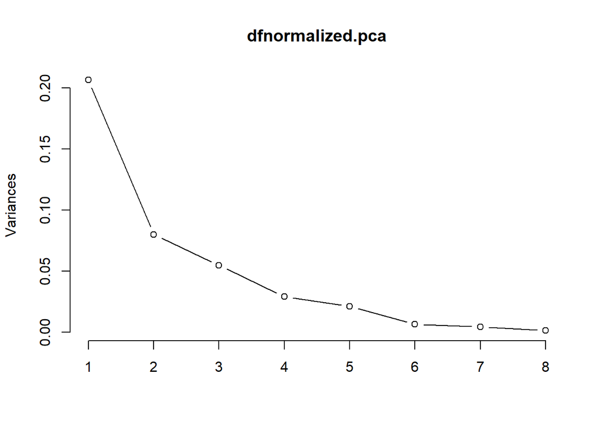

```r
plot(dfnormalized.pca,type="l")
```

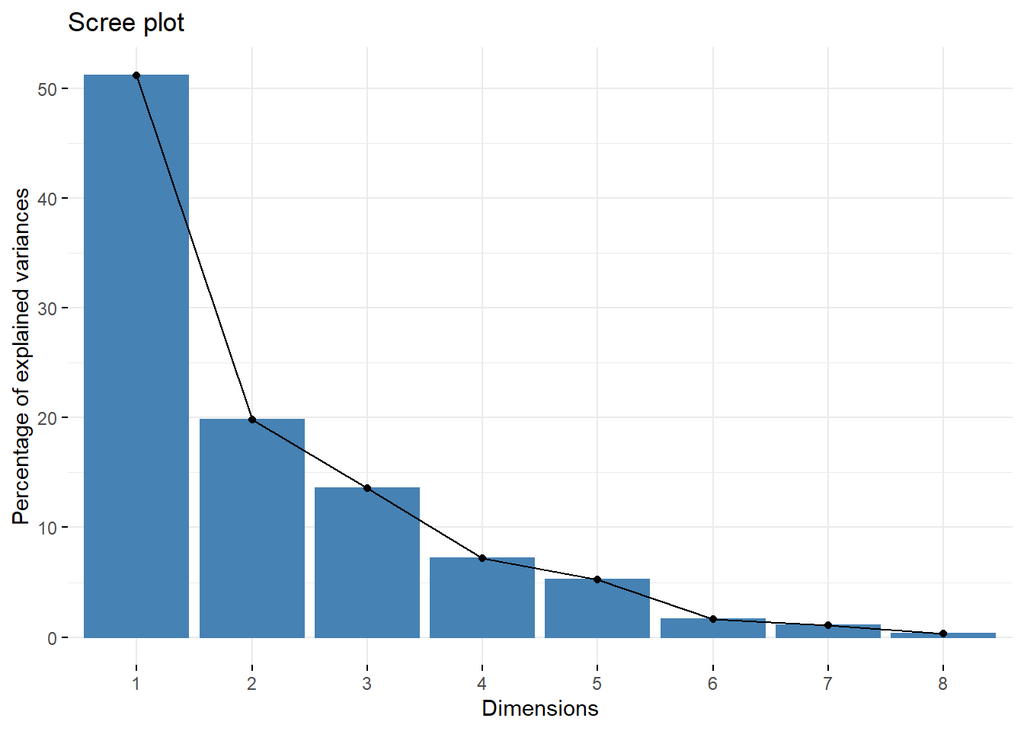

```r
fviz_eig(dfnormalized.pca)
```

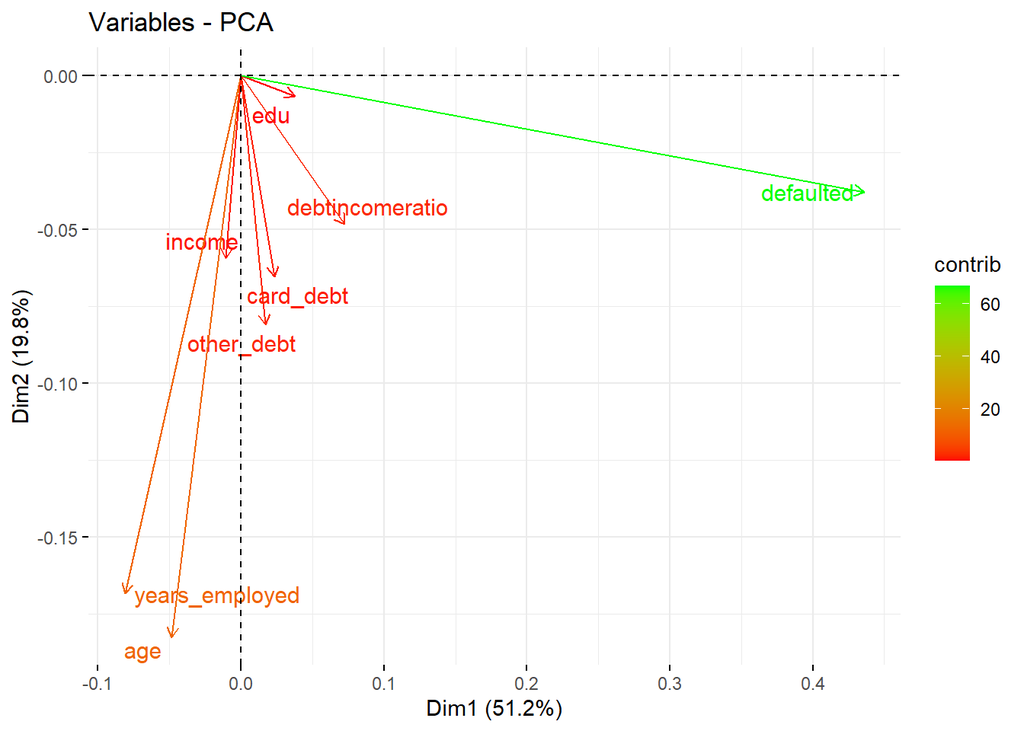

```r
fviz_pca_var(dfnormalized.pca,
             col.var = "contrib", # Color by contributions to the PC
             gradient.cols = c("red", "green"),
             repel = TRUE     # Avoid text overlapping
             )
```

Graph of variables contributing to PC1(on the right side of thegraph ,they include defaulted,debt income ratio,card debt,other debt and edu).

# optimization

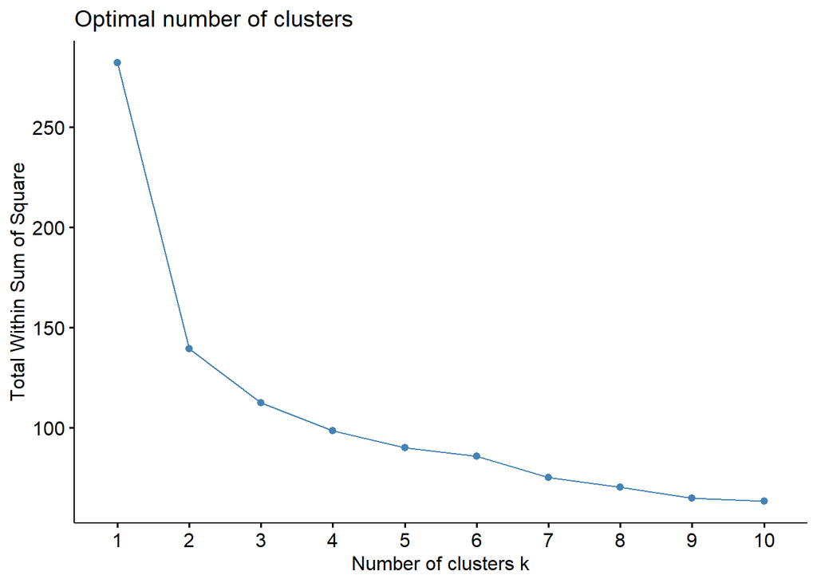

```r
# Determining Optimal clusters (k) Using Elbow method
fviz_nbclust(x = dfnormalized,FUNcluster = kmeans, method = 'wss' )
```

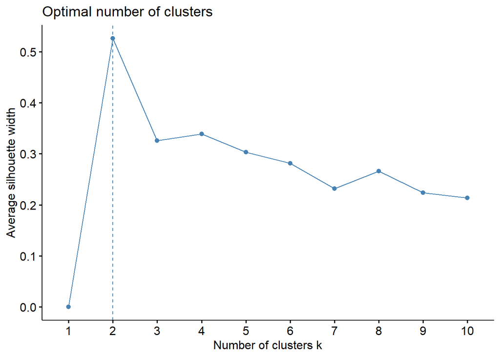

```r
# Determining Optimal clusters (k) Using silhoutte method
fviz_nbclust(x = dfnormalized,FUNcluster = kmeans, method = 'silhouette' )
```

[output not shown]

[output cut: 14 more lines]

[output not shown]

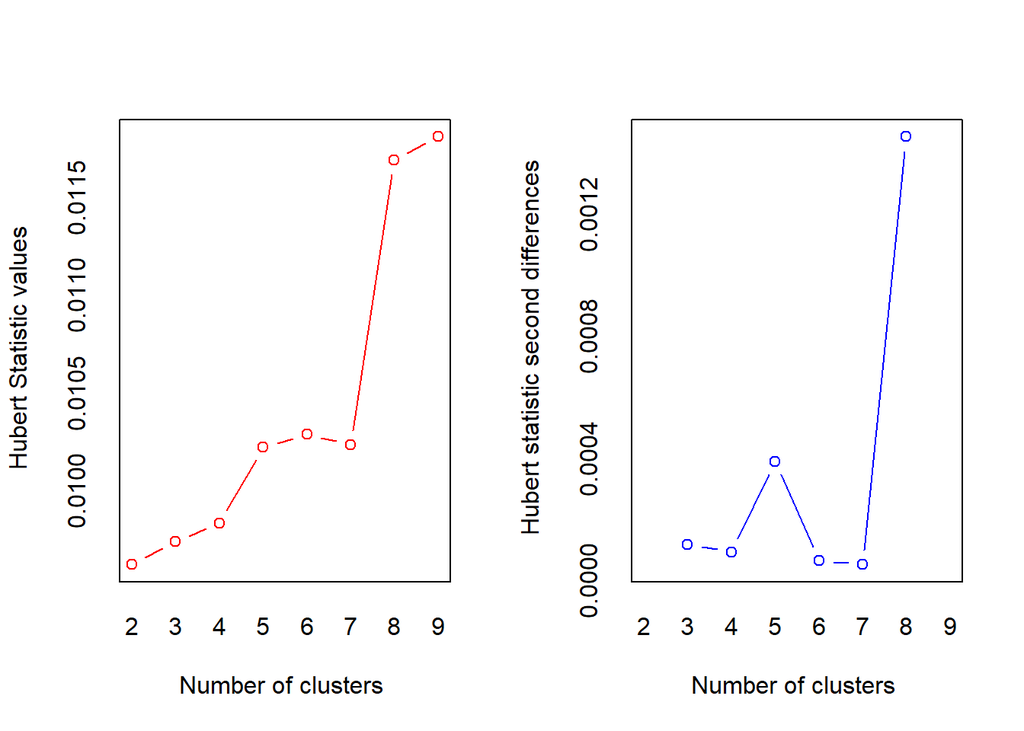

```
## *** : The Hubert index is a graphical method of determining the number of clusters.
##                 In the plot of Hubert index, we seek a significant knee that corresponds to a
##                 significant increase of the value of the measure i.e the significant peak in Hubert
##                 index second differences plot.
##
```

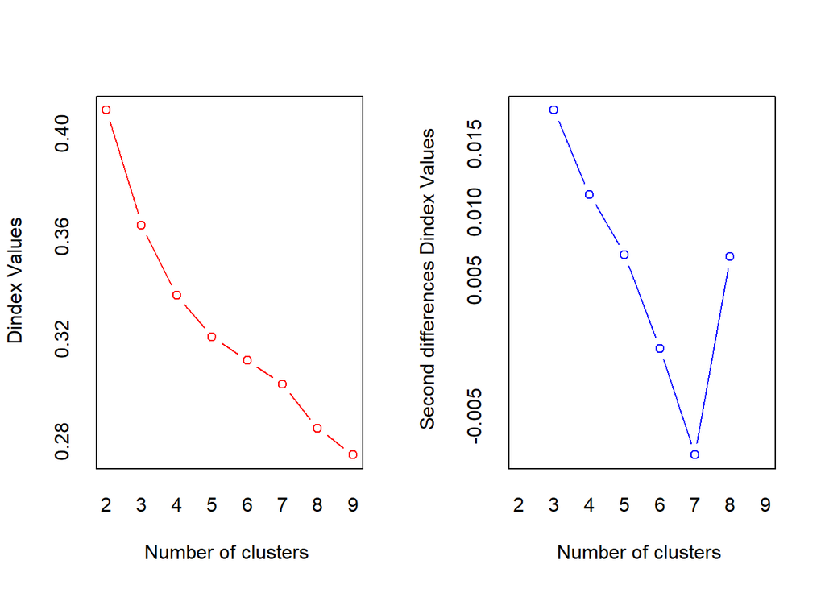

```
## *** : The D index is a graphical method of determining the number of clusters.
##                 In the plot of D index, we seek a significant knee (the significant peak in Dindex
##                 second differences plot) that corresponds to a significant increase of the value of
##                 the measure.
##
## * Among all indices:
## * 9 proposed 2 as the best number of clusters
## * 8 proposed 3 as the best number of clusters
## * 1 proposed 5 as the best number of clusters
## * 2 proposed 7 as the best number of clusters
## * 2 proposed 8 as the best number of clusters
## * 2 proposed 9 as the best number of clusters
##
##                    ***** Conclusion *****
##
## * According to the majority rule, the best number of clusters is  2
##
##
```

```r
# Determining Optimal clusters (k) Using nbclust method
library("NbClust")
res.nbclust <- NbClust(dfnormalized, distance = "euclidean",
                  min.nc = 2, max.nc = 9,
                  method = "kmeans", index ="all")
```

```
## Among all indices:
## ===================
## * 2 proposed  0 as the best number of clusters
## * 9 proposed  2 as the best number of clusters
## * 8 proposed  3 as the best number of clusters
## * 1 proposed  5 as the best number of clusters
## * 2 proposed  7 as the best number of clusters
## * 2 proposed  8 as the best number of clusters
## * 2 proposed  9 as the best number of clusters
##
## Conclusion
## =========================
## * According to the majority rule, the best number of clusters is  2 .
```

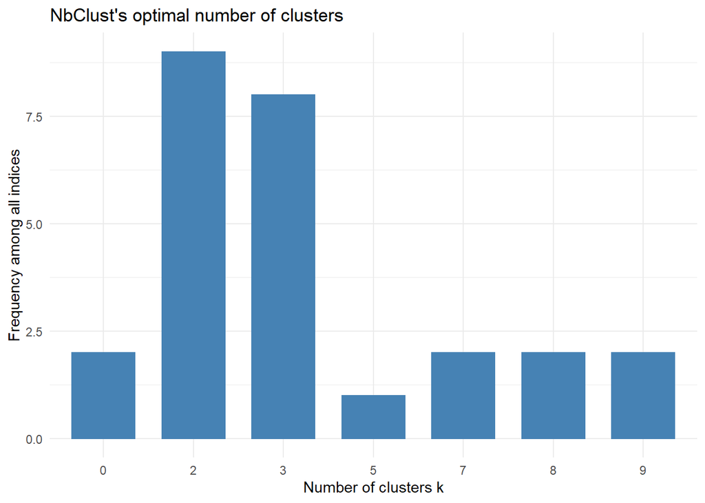

```r
factoextra::fviz_nbclust(res.nbclust) + theme_minimal() + ggtitle("NbClust's optimal number of clusters")
```

All three approaches suggested 2 as the number of optimal clusters, we can perform the final analysis and extract the results using 2 clusters.

```r
# Applying the K-means clustering algorithm with no. of centroids(k)=2
set.seed(564)
clusters<- kmeans(dfnormalized,2,nstart=25)
```

```r
# Previewing the no. of records in each cluster

clusters$size
```

```
## [1] 517 183
```

```r
# Getting the value of cluster center
# ---
#
clusters$centers
```

```
##         age       edu years_employed     income  card_debt other_debt defaulted
## 1 0.4309585 0.1648936      0.3067324 0.07674708 0.06002786  0.1010593         0
## 2 0.3614147 0.2254098      0.1685175 0.06299332 0.11737106  0.1414263         1
##   debtincomeratio
## 1       0.2024280
## 2       0.3503146
```

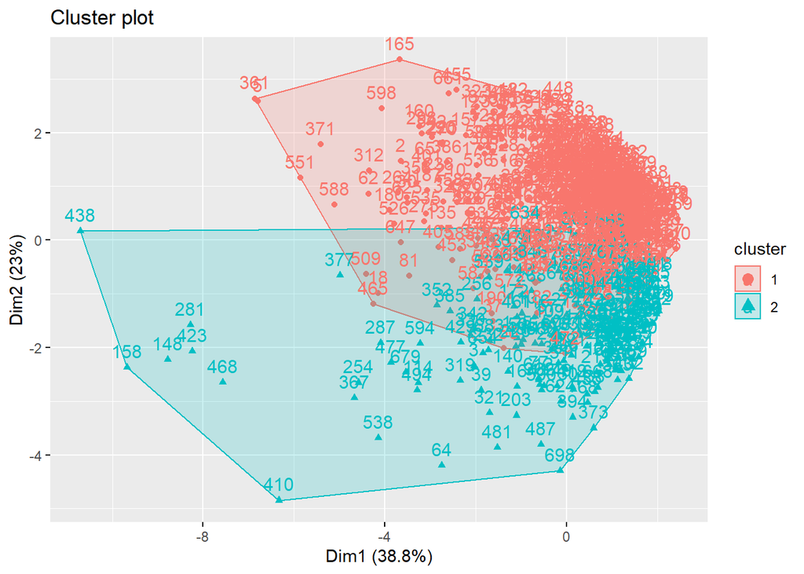

```r
#visualize the cluster  so far
#
fviz_cluster(clusters, data = dfnormalized)
```

```r
# Or subset on the default 0/1
# defaulted =1
# not defaulted =0
dfdefault <- subset(dfnormalized, dfnormalized$default ==1)
dfdefault
```

[output not shown]

[output cut: 353 more lines]

```r
# Or subset on the default 0/1
# defaulted =1
# not defaulted =0
dfdefault <- subset(dfnormalized, dfnormalized$default ==0)
dfdefault
```

[output not shown]

[output cut: 1021 more lines]

```r
# Clusters to which each point is associated
clusters$cluster
```

```
##   [1] 1 1 2 1 1 1 1 1 2 1 2 1 1 1 1 2 1 1 1 1 1 1 1 2 1 2 2 1 2 1 1 1 1 1 1 1 1
##  [38] 2 2 2 2 1 1 1 1 1 1 1 1 1 1 2 1 2 1 1 1 1 1 1 1 1 1 2 1 1 2 2 1 1 2 2 1 1
##  [75] 2 1 2 1 2 2 1 1 1 1 1 1 1 2 1 1 1 1 1 1 1 1 1 1 1 1 1 1 1 1 1 1 1 1 2 2 1
## [112] 1 1 2 1 2 1 1 1 2 1 1 1 2 2 1 1 1 1 1 1 1 1 1 1 1 1 2 1 2 1 1 2 1 2 1 1 2
## [149] 2 1 1 1 1 2 1 1 1 2 1 1 2 1 2 1 1 1 2 1 1 1 2 2 1 2 1 1 1 1 1 1 1 1 2 1 1
## [186] 1 1 1 2 1 1 1 1 1 1 1 1 1 1 1 1 1 2 1 2 1 1 1 2 1 2 1 1 1 2 1 1 2 2 2 1 1
## [223] 1 1 1 1 1 1 1 1 1 2 1 1 2 1 2 1 1 1 1 1 2 1 1 2 1 1 1 1 1 2 2 2 1 2 1 1 2
## [260] 2 1 1 1 1 2 1 1 2 1 1 1 1 1 2 1 1 1 1 1 1 2 1 1 1 1 1 2 1 1 1 2 1 2 1 1 1
## [297] 1 1 1 2 1 1 2 2 1 1 2 1 1 1 1 1 1 1 1 1 1 1 2 1 2 1 1 1 1 1 2 1 1 2 2 1 1
## [334] 1 1 2 2 1 2 1 1 2 1 1 1 2 1 1 1 2 1 2 1 1 1 1 1 1 1 1 1 2 1 1 1 1 2 2 1 1
## [371] 1 1 2 1 1 1 2 1 1 1 1 1 1 1 2 1 1 1 1 2 1 1 1 2 2 1 1 1 1 1 1 2 2 1 1 1 1
## [408] 1 2 2 2 2 2 2 1 1 2 1 2 2 1 2 2 1 2 1 2 1 2 1 2 1 2 2 2 1 1 2 1 2 1 1 2 1
## [445] 2 1 1 1 2 1 1 1 1 1 1 1 2 1 1 1 2 2 1 1 1 1 1 2 1 2 1 1 1 2 2 2 2 2 1 1 2
## [482] 1 1 1 1 2 2 1 1 1 1 1 2 2 1 1 1 2 1 1 2 1 1 2 2 2 2 1 1 2 2 1 1 1 1 1 2 1
## [519] 1 1 1 1 1 1 1 1 2 1 1 2 1 1 2 1 1 1 1 2 2 1 1 1 1 1 1 1 1 2 1 1 1 1 1 1 1
## [556] 1 1 1 1 2 1 1 2 1 1 1 1 2 1 1 1 1 1 1 2 1 2 1 2 2 1 1 1 2 1 1 1 1 1 2 1 1
## [593] 1 2 1 1 1 1 1 2 1 1 1 1 1 1 1 1 1 1 1 2 1 1 1 1 1 1 1 2 1 1 1 2 1 1 1 1 1
## [630] 2 1 1 1 2 2 1 2 1 1 1 1 1 1 1 1 1 1 1 1 1 1 1 1 2 2 1 2 1 1 1 1 2 1 1 1 1
## [667] 1 2 1 2 1 1 2 1 1 1 2 2 2 1 1 1 2 1 1 1 1 1 1 1 1 1 1 1 1 1 1 2 1 1
```